# How disrupted spatial fluxes reshape food web structure along the river–sea continuum

Author

Ismaël Lajaaiti, Eric Edeline, Anik Brind’Amour, Alain Danet

## Abstract

Anthropic disturbances and ecosystem processes transcend the artificial boundaries between land, freshwater, and sea. While these systems are interconnected through species and material fluxes, they are often studied in isolation. In response, the concept of metaecosystem has emerged as a powerful framework to understand how fluxes among ecosystems shape their functions and dynamics. Disrupting these fluxes can have dramatic consequences that ripple across entire landscapes. In aquatic systems, dams and nutrient pollution are known to strongly affect fish communities. Yet, little is still known about how these effects propagate and potentially accumulate, through hydrographic basins and ultimately to the sea. Using bayesian spatio-temporal statistical models (R-INLA), we aim to analyse existing data on food-web structure across France, combined with environmental variables (dams, nutrients, …), to quantify how breaking or increasing fluxes among systems disturbs food-web structure locally and how these disturbances spread throughout the metaecosystem.

**Keywords:** *foodweb ecology, stream network, spatial autocorrelation, bayesian statistics.*

## Introduction

While patterns in community change within river network have been well studied, these studies have mostly focus on specise richness (Bonnaffé et al. 2024), or roughly defined functional composition (Vannote et al. 1980).

- Barnes et al. (2026) food web complexity mediates diversity-functioning relationship. Interesting metric of trophic complementarity, could be used for our study if we can formulate clear hypothesis of stressors on that metric.

### River-estuary-sea continuum

- Xenopoulos et al. (2017) highlights the importance of accounting for the full gradient from headwater to the sea. Freshwater and coastal ecosystems are connected by flux of carbone and nutrients (N, P), as well as, movement of migratory species. Reviews work connecting river and sea, that said, most of them focus on chemical fluxes, remain relatively local, and none of them focused on the food web structure.
- Catchment land-use impacts macro-invertebrates along the river-sea continuum with no dilution effect (Bierschenk et al. 2017).
- The Land-to-Ocean Continuum (LOAC) concept has been used to study carbon fluxes between land and ocean, and how these fluxes, and feedback loop influence the carbon storage by oceans (Regnier et al. 2022).
- Hong et al. (2015) Editorial overview of studies investigating the impact of human pressure along the river-estuary-sea continuum, more focused toward biochemistry than ecology.
- Ouellet et al. (2022) provides a conceptual model (DWOC) to advance a more holistic management of diadromous species across the watersheds-ocean continuum.
- Tee et al. (2021) studies the river-to-sea continuum of microbial communities through community composition and their function (nutrient cycling).
- Whitfield et al. (2024) reviews how species richness changes along the salinity gradient in estuaries. As we go to freshwater to brackish water we loose species richness, and as we to brackish water to the sea we recover species richness.
- Elliott and Quintino (2007) argues that it is difficult to detect the effect of anthropogenic pressure in estuary as estuaries are already stressed environment. In particular, this means thinking about the indicators used to describe ecosystem states (diversity, and functionning).
- Little et al. (2017) Lechêne et al. (2018) Olli et al. (2019) and Freitas and Araújo (2025) study how communities change along environmental gradient in estuaries.
- Attrill (2002) critiques Remane diagram and proposes and quantitive, testable alternative that consider salinity ranges instead of salinity.
- Macedo et al. (2021) Food webs are simpler during the dry season than the rainy season in the estuarine and neritic zones. During the rainy season, the food web of the neritic is largely shaped by migratory species from the estuarine and oceanic areas.
- Álvarez-Romero et al. (2015) proposes an integrated framework to include land-use change in cactchement in the impact on coastal biodiversity.

### Freshwater ecosystems

- The River Continuum Concept has shaped the freshwater ecology researsh by links physical gradients along rivers to predictable changes in community structure, energy sources, and ecosystem functioning (Vannote et al. 1980; Doretto et al. 2020).
- Serial Discontinuity Concept is a framework to predict the impact of discontinuities, such as dams, on biotic and abiotic variables along the river continuum (Ward and Stanford 1995).
- The Flood Pulse Concept (FPC) complements the RCC as it focuses on the lateral dimension of rivers and its role in explaining community productivity, while the RCC focused on the longitudinal aspect. The FPC states that its the rythm of flood and recession – that is, the pulse – which structures ecosystem productivity, not the flow (Junk et al. 1989).
  - Terrestrial organic matter (leaf litter, vegetation, soil nutrients) gets dissolved and mobilized into the water
  - Aquatic plants and algae explode in productivity in the shallow, sunlit floodwaters
  - Fish and invertebrates move onto the floodplain to feed and reproduce
  - When waters recede, nutrients and organic matter flush back into the main channel
- The River Wave concept as unifying framework of different concepts of freshwater ecology (Humphries et al. 2014).
- Community richness and hence food web structure is expected to be driven by nutrient availability (Ho et al. 2023).

### Multiple stressors

- Synergistic and antagonistic effects of multiple stressors (Jackson et al. 2021; Orr et al. 2024).
- Temperature can interact with nutrients and impact food web structure in a nonlinear way Binzer et al. (2012).
- (Danet et al. 2021; Bonnaffé et al. 2024).

### Connectivity

- Small dispersal stabilizes through spatial structure and asynchrony (LeCraw et al. 2014; McCann et al. 2005; Pillai et al. 2011).
- A metaecosystem model shows that dispersal of living organisms (that consume nutrients) is stabilising,while dispersal of non-living compartments such as nutrients or detritus is destabilising (Gounand et al. 2014).
- Prey switching of mobile top predators can stabilize connected food webs through ‘spatial coupling’ (LeCraw et al. 2014; McCann et al. 2005; Pillai et al. 2011).
- At high dispersal/connectivity the stabilizing effect wanes as strongly connected patches behave as a single patch (LeCraw et al. 2014; McCann et al. 2005).
- Studies between pairs of the following connectivity, complexity and stability are common. However, studies investigating how these are interconnected are rare (LeCraw et al. 2014).
- Connectivity has 4 dimensions: longitudinal, lateral, vertical and temporal (Grill et al. 2019).
- We identified five pressure factors to represent the main human interferences within the four dimensions of fluvial or river connectivity (Grill et al. 2019):
  1. river fragmentation (longitudinal);
  2. flow regulation (lateral and temporal);
  3. sediment trapping (longitudinal, lateral and vertical);
  4. water consumption (lateral, vertical and temporal);
  5. infrastructure development in riparian areas and floodplains (lateral and longitudinal).
- In freshwater system, fish dispersal is limited. A meta-analysis found that the mean dispersal kernel is around 10km (Comte and Olden 2018).
- Neutral metacommunity model explains biodiversity pattern in the Mississipi river, showing the key role of dispersal in explaining community structure along the river continuum (Muneepeerakul et al. 2008).
- Connectivity structures and mititgates effect of drying events in macroinvertebrates communities (Chalmandrier et al. 2025).
- It is key to adopt a network perspective to understand how diversity is created and maintained within riverine ecosystems (Altermatt 2013). With this perspective one can account for the dendritic network and so the spatial processes that shape diversity.
- From points (Death and Winterbourn 1995)… to lines (RCC, SDC)… to dendritic networks (Shepherd and Ellis 1997).
- River network characteristics, local network properties and their interaction were important individual contributors to explaining local species richness of aquatic insects (Altermatt et al. 2013). Effect of connectivity on richness supported experimentally (Carrara et al. 2012).

### Decomposing spatio-temporal patterns

- Frelat et al. (2022) decompose change in food web structure and species composition across space and time using a tensor decomposition. We could probably try the method for our work.
- Kortsch et al. (2021) investigates change in food web in the Baltic Sea using weighted and unweighted structural metrics.

### Dams

- Decrease river connectivity / reduce migration (Dean et al. 2023; He et al. 2024; Pedersen et al. 2012).
- Reservoir, lotic from lentic conditions, can result in hypoxic conditions. Favor phytoplancktons and macrophytes (Ding et al. 2026; Dean et al. 2023). Facilitate the spread of invasive species (Johnson et al. 2008).
- Reservoir increase residence time of nutrients upstream and decrease the downstream output, which can result in a decrease in primary productivity.
- Hydropeaking - that is, the sudden release of large water to answer the higher electric demand - can harm riverine community due to sudden change in water level and water flow.
- Cumulative impact of dams can reduce the nutrient input in deltas (Dean et al. 2023).
- A review (Ellis and Jones 2013) suggests that two recovery gradients exist in regulated river:
  1. a longer, thermal gradient of around 100 km;
  2. a shorter resource subsidy gradient of around 1-4 km.
- Zhu et al. (2024) shows that dam areas show lowest richness and highest connectance, while areas with dam removed show highest richness but lowest connectance.
- Dolan et al. (2026) Meta-analysis shows that native and non-native species increased after barrier removal, but the positive effect was strongest for native species

### Nutrients

- Mwanake et al. (2026) DOC-to-nutrient ratios in river decline worldwide
- Ma et al. (2026) finds that human impact destabilize riverine fish communities, but habitat complexity buffers this destabilizing effect.

### Meta-ecosystems

- Loreau et al. (2003) fundational paper that defines the concept of meta-ecosystem.
- Polis et al. (1997) founding synthesis of how spatial subsidy, flux of consumer and resources reorganise food webs.
- Spaak et al. (2026) provide a metric of coupling between ecosystems based on the Jacobian.

### Traits

- Brosse et al. (2021) FISHMORPH database which contains 10 morphological traits for around 50% of freshwater fish species worldwide.

## Hypotheses

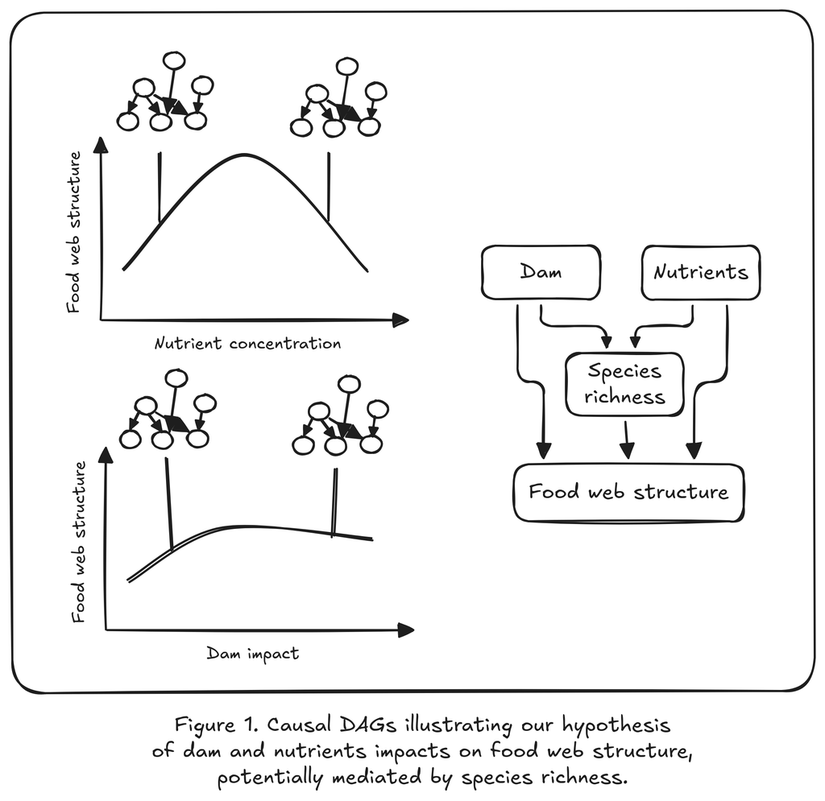

We focus on three structural metrics with well-developed theoretical expectations: **connectance**, **mean trophic level**, and a **trophic complementarity** metric following Barnes et al. (2026).

**H2 — Dam impact affects food web structure through (at least) two distinct pathways, at two different spatial scales, which we predict act on different metrics.** We distinguish a *local* pathway (distance to nearest dam) from a *global* pathway (cumulative barrier effect / basin-wide fragmentation, per AMOBIO’s existing metrics). At the basin scale, cumulative fragmentation is expected to reduce species richness and mean trophic level, through loss of migratory and piscivorous species that depend on longitudinal connectivity (Dean et al. 2023; He et al. 2024). At the same time, dams are known to facilitate the spread of invasive species (Johnson et al. 2008), including generalist invasive predators such as wels catfish (*Silurus glanis*) — reservoirs can provide favorable larval-rearing habitat that promotes range expansion, and the species is known to reshape recipient fish communities once established (Encina et al. 2024; Bylak et al. 2023). If such generalists establish disproportionately in impounded reaches, we would predict connectance to *increase* as richness and trophic complementarity trophic level decline.

**H3 — Part of the dam and nutrient effects on food web structure is mediated by species richness, but we expect a direct effect too.** Consistent with the DAG above, candidate direct-effect mechanisms — i.e. effects on structure that don’t operate simply by adding or removing species — in particular the compositional/identity effect described in H2, where an invasive generalist changes connectance through its trophic role rather than through a change in richness per se. Methodologically, we plan to fit two linked INLA models — richness ~ dam + nutrients + spatial structure, and structure ~ dam + nutrients + richness + spatial structure — and compute the indirect effect as the product of posterior samples of the relevant coefficients across the two fits. This gives a fully Bayesian direct/indirect decomposition inside the INLA framework itself, with the (Bayesian) SEM run alongside as an independent cross-check rather than the sole source of the decomposition.

**H4 — A site’s position along the river-to-sea continuum modulates its sensitivity to both stressors, and we expect this sensitivity to peak in the estuarine transition zone; both stressors may also propagate over long distances rather than acting only locally.** Upstream (riverine) and downstream (marine) sites differ systematically in baseline connectivity, salinity, and community composition (Whitfield et al. 2024; Attrill 2002). We predict that the *slope* of the nutrient effect (and possibly the dam-impact effect) on food web structure — i.e. an interaction between continuum position and stressor magnitude — is not uniform along the continuum. Specifically, because estuaries are naturally physiologically stressful environments (fluctuating salinity, turbidity, low baseline diversity), resident communities may already sit closer to their tolerance limits and hence be more sensitive to added anthropogenic pressure (Elliott and Quintino 2007) — consistent with synergistic rather than additive multiple-stressor dynamics in already-stressed systems (Jackson et al. 2021). This contrasts with a simple monotonic view in which sensitivity would only increase or decrease steadily from headwater to sea. Note this pairs naturally with the local/global distinction in H2: the basin-wide barrier effect and nutrient loading are both plausibly long-distance-acting pressures, which is part of why we model both a local (distance) and a global (cumulative) dam metric rather than distance alone.

## Methods

### Food web inference

To infer local food web structure, we used a metaweb approach. That is, we build a web compiling the potential feeding interactions between all species of the dataset. Importantly, our metaweb takes into account intra-specific variation in species diet. We did so by defining trophic interactions at different life stages for each species.

#### Infer missing fish lengths

Most length of fishes are measured but not all. Yet, we need individual fish length to determine their diet based on their ontogeny. We infer missing fish size using information on the given fishing operation. When there are more than three observations of the fish species, we use a truncated normal distribution (package truncdist; Nadarajah and Kotz (2006)). The mean and variance are given by the modes of the observed distribution of the fishing operation. The minimum and maximum of the distribution are given by the minimal and maximal length observed on the entire data set for that species. We do so to avoid infering irrealistic lengths.

#### Get fish diet

We use fishbase as a primary source to extract fish diet at their different life stages, to get on which basal categories species feed on and whether they are piscivorous or not. We detail in the Supporting Information how made the correspondance between our categories and the one of fishbase. We remove species that have an occurence lower than 10 in the entire dataset which comprise 69 species. This enable to avoid retrieving diet information of species that will have a minimal impact on food web structure due to their rarity. We add a larvae stage when missing, assuming that fish larvae feed on zooplankton (Dabrowski 1984). We assume that fish individuals are larvae if they measure less than 2 cm. To classify individuals as juvenile or adult we use the length at maturity of the species as a threshold. When this information was not available we used a single stage (*combined*) by merging the diets of the two stages. We did not consider a recruit stage.

#### The metaweb

Predation window are assumed to be 0.03 to 0.45 of individual body size for piscivorous species. We then use the package foodwebbuilder to build the metaweb and the local food webs through subsampling. We investigated the effect of the number of size classes on the structure of the reconstructed metaweb. We observed little influence of the number of size classes on the metaweb connectance Figure S3. So, we decided to split each species 5 size classes as in Bonnaffé et al. (2024).

**Note**

The choice of a constant predation window has an important implication. It implies that what only matters in terms of ecosystem functioning is the individual size (once the species is known to be piscivorous). In this setting, two piscivorous individual of different species but same size will eat the very same things.

## Results

[figure not shown]

[figure not shown]

## Discussion

### Limitations

Regarding food web structure, we have simplified the base of the web and exclude macro-invertebrates. This choice naturally emphasizes the functional role of fishes in shaping food web structures. Yet, it would be valuable to include macro-invertebrates within the food web to get a more exhaustive picture of how aquatic community respond to stressors along the riversea continuum.

# Supporting Information

## Structure of the food web base

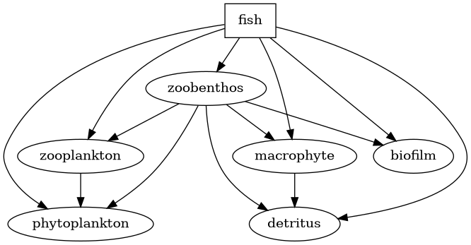

Figure S1: Assumed structure of the food web base.

## Venn diagramm

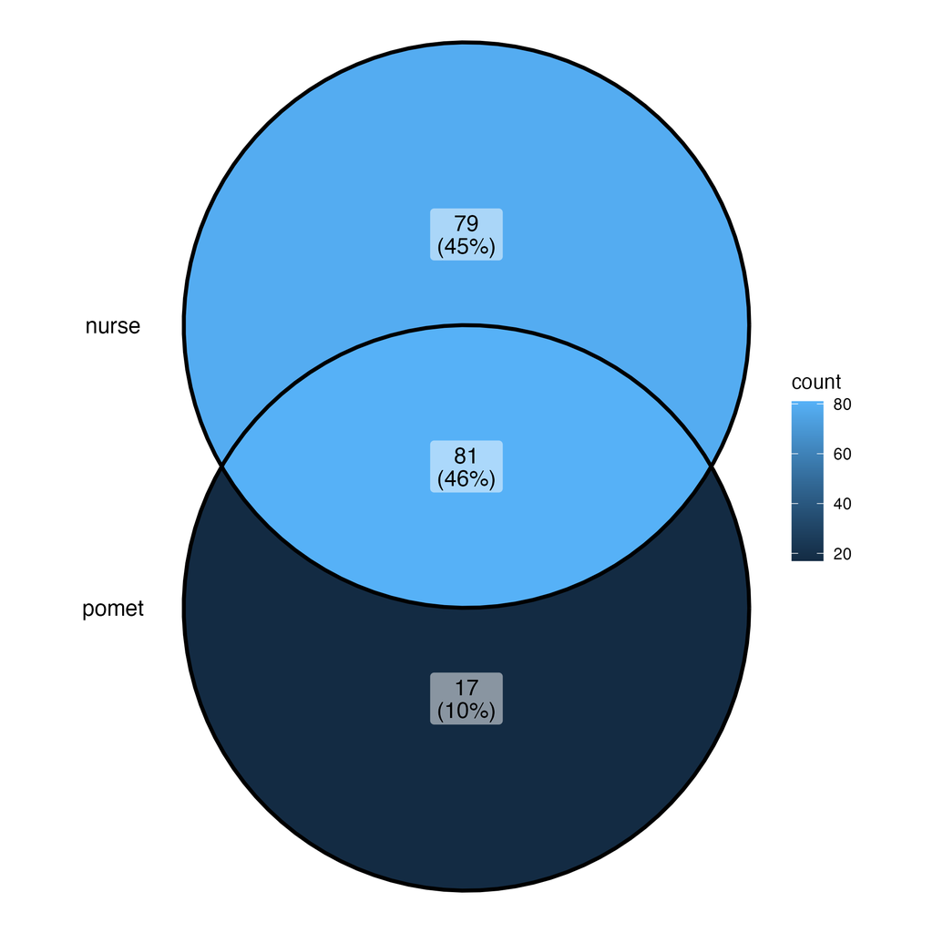

Figure S2: Venn diagram of common species between surveys.

## Number of size classes and metaweb structure

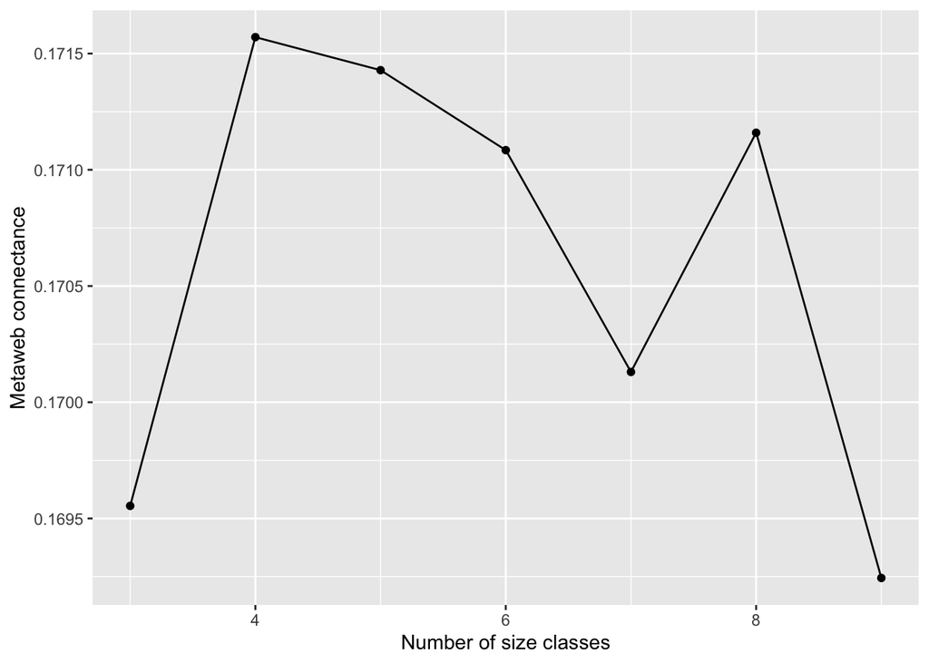

```r
targets::tar_read(plot_metaweb_connectance)
```

Figure S3: How metaweb connectance varies with the number of size classes.

## References

Altermatt, Florian. 2013. “Diversity in Riverine Metacommunities: A Network Perspective.” *Aquatic Ecology* 47 (3): 365–77. https://doi.org/10.1007/s10452-013-9450-3.

Altermatt, Florian, Mathew Seymour, and Nicolas Martinez. 2013. “River Network Properties Shape α-Diversity and Community Similarity Patterns of Aquatic Insect Communities Across Major Drainage Basins.” *Journal of Biogeography* 40 (12): 2249–60. https://doi.org/10.1111/jbi.12178.

Álvarez-Romero, Jorge G., Robert L. Pressey, Natalie C. Ban, and Jon Brodie. 2015. “Advancing Land-Sea Conservation Planning: Integrating Modelling of Catchments, Land-Use Change, and River Plumes to Prioritise Catchment Management and Protection.” *PLOS ONE* 10 (12): e0145574. https://doi.org/10.1371/journal.pone.0145574.

Attrill, Martin J. 2002. “A Testable Linear Model for Diversity Trends in Estuaries.” *Journal of Animal Ecology* 71 (2): 262–69. https://doi.org/10.1046/j.1365-2656.2002.00593.x.

Barnes, Andrew D., Ulrich Brose, Nico Eisenhauer, et al. 2026. “Food Web Complexity Underlies Biodiversity Effects on Ecosystem Functioning.” *Nature*, July 1, 1–7. https://doi.org/10.1038/s41586-026-10710-5.

Bierschenk, Antje M., Candida Savage, and Christoph D. Matthaei. 2017. “Intensity of Catchment Land Use Influences Biological Traits of Benthic Invertebrates Along a Freshwater-Marine Continuum.” *Limnology and Oceanography* 62 (S1): S292–308. https://doi.org/10.1002/lno.10584.

Binzer, Amrei, Christian Guill, Ulrich Brose, and Björn C. Rall. 2012. “The Dynamics of Food Chains Under Climate Change and Nutrient Enrichment.” *Philosophical Transactions of the Royal Society B: Biological Sciences* 367 (1605): 2935–44. https://doi.org/10.1098/rstb.2012.0230.

Bonnaffé, Willem, Alain Danet, Camille Leclerc, Victor Frossard, Eric Edeline, and Arnaud Sentis. 2024. “The Interaction Between Warming and Enrichment Accelerates Food-Web Simplification in Freshwater Systems.” *Ecology Letters* 27 (8): e14480. https://doi.org/10.1111/ele.14480.

Brose, Ulrich, Richard J. Williams, and Neo D. Martinez. 2006. “Allometric Scaling Enhances Stability in Complex Food Webs.” *Ecology Letters* 9 (11): 1228–36. https://doi.org/10.1111/j.1461-0248.2006.00978.x.

Brosse, Sébastien, Nicolas Charpin, Guohuan Su, et al. 2021. “FISHMORPH: A Global Database on Morphological Traits of Freshwater Fishes.” *Global Ecology and Biogeography* 30 (12): 2330–36. https://doi.org/10.1111/geb.13395.

Bylak, Aneta, Krzysztof Kukuła, Ryan Easton, Malcolm Reid, and Gerard P. Closs. 2023. “Reservoirs Facilitate Colonization of River Catchments by a Native Invasive Fish Through Provision of Pelagic Larval Rearing Habitat.” *Biological Invasions* 25 (5): 1541–59. https://doi.org/10.1007/s10530-023-02995-8.

Carrara, Francesco, Florian Altermatt, Ignacio Rodriguez-Iturbe, and Andrea Rinaldo. 2012. “Dendritic Connectivity Controls Biodiversity Patterns in Experimental Metacommunities.” *Proceedings of the National Academy of Sciences* 109 (15): 5761–66. https://doi.org/10.1073/pnas.1119651109.

Chalmandrier, Loïc, David Cunillera-Montcusí, Naiara López-Rojo, et al. 2025. “Natural Disturbances and Connectivity Drive Seasonal Taxonomic and Trait Patterns of Aquatic Macroinvertebrate Communities Across Europe.” *Global Ecology and Biogeography* 34 (5): e70047. https://doi.org/10.1111/geb.70047.

Comte, Lise, and Julian D. Olden. 2018. “Fish Dispersal in Flowing Waters: A Synthesis of Movement- and Genetic-Based Studies.” *Fish and Fisheries* 19 (6): 1063–77. https://doi.org/10.1111/faf.12312.

Dabrowski, K. 1984. “The Feeding of Fish Larvae : Present « State of the Art » and Perspectives.” *Reproduction Nutrition Développement* 24 (6): 807–33. https://doi.org/10.1051/rnd:19840701.

Danet, Alain, Maud Mouchet, Willem Bonnaffé, Elisa Thébault, and Colin Fontaine. 2021. “Species Richness and Food-Web Structure Jointly Drive Community Biomass and Its Temporal Stability in Fish Communities.” *Ecology Letters* 24 (11): 2364–77. https://doi.org/10.1111/ele.13857.

Dean, E. M., Dana M. Infante, Hao Yu, Arthur Cooper, Lizhu Wang, and Jared Ross. 2023. “Cumulative Effects of Dams on Migratory Fishes Across the Conterminous United States: Regional Patterns in Fish Responses to River Network Fragmentation.” *River Research and Applications* 39 (9): 1736–48. https://doi.org/10.1002/rra.4173.

Death, Russell G., and Michael J. Winterbourn. 1995. “Diversity Patterns in Stream Benthic Invertebrate Communities: The Influence of Habitat Stability.” *Ecology* 76 (5): 1446–60. https://doi.org/10.2307/1938147.

Ding, Na, Zunyi Xie, Xiaoming Wang, et al. 2026. “Freshwater Biodiversity Impacts of Global Hydropower Dams.” *Communications Earth & Environment*, ahead of print, February 9. https://doi.org/10.1038/s43247-026-03263-y.

Dolan, Ellen J., Ismael Soto, Julian D. Olden, et al. 2026. “Native and Non-Native Populations Respond Unevenly to River Barrier Removals.” *Global Change Biology* 32 (6): e70941. https://doi.org/10.1111/gcb.70941.

Doretto, Alberto, Elena Piano, and Courtney E. Larson. 2020. “The River Continuum Concept: Lessons from the Past and Perspectives for the Future.” *Canadian Journal of Fisheries and Aquatic Sciences* 77 (11): 1853–64. https://doi.org/10.1139/cjfas-2020-0039.

Elliott, Michael, and Victor Quintino. 2007. “The Estuarine Quality Paradox, Environmental Homeostasis and the Difficulty of Detecting Anthropogenic Stress in Naturally Stressed Areas.” *Marine Pollution Bulletin* 54 (6): 640–45. https://doi.org/10.1016/j.marpolbul.2007.02.003.

Ellis, Lucy Eunsun, and Nicholas Edward Jones. 2013. “Longitudinal Trends in Regulated Rivers: A Review and Synthesis Within the Context of the Serial Discontinuity Concept.” *Environmental Reviews* 21 (3): 136–48. https://doi.org/10.1139/er-2012-0064.

Encina, Lourdes, Amadora Rodríguez-Ruiz, Carlos Orduna, Juan Ramón Cid, de Meo Ilaria, and Carlos Granado-Lorencio. 2024. “Impact of Invasive European Catfish (Silurus Glanis) on the Fish Community of Torrejón Reservoir (Central Spain) During a 11-Year Monitoring Study.” *Biological Invasions* 26 (3): 745–56. https://doi.org/10.1007/s10530-023-03204-2.

Freitas, Leonardo Almeida, and Francisco Gerson Araújo. 2025. “Assessing Fish Community Structure and Diversity Across Environmental Gradients in a Tropical Bay.” *Marine Ecology* 46 (2): e70016. https://doi.org/10.1111/maec.70016.

Frelat, Romain, Susanne Kortsch, Ingrid Kröncke, et al. 2022. “Food Web Structure and Community Composition: A Comparison Across Space and Time in the North Sea.” *Ecography* 2022 (2). https://doi.org/10.1111/ecog.05945.

Gounand, Isabelle, Nicolas Mouquet, Elsa Canard, Frédéric Guichard, Céline Hauzy, and Dominique Gravel. 2014. “The Paradox of Enrichment in Metaecosystems.” *The American Naturalist* 184 (6): 752–63. https://doi.org/10.1086/678406.

Grill, G., B. Lehner, M. Thieme, et al. 2019. “Mapping the World’s Free-Flowing Rivers.” *Nature* 569 (7755): 215–21. https://doi.org/10.1038/s41586-019-1111-9.

He, Fengzhi, Christiane Zarfl, Klement Tockner, et al. 2024. “Hydropower Impacts on Riverine Biodiversity.” *Nature Reviews Earth & Environment* 5 (11): 755–72. https://doi.org/10.1038/s43017-024-00596-0.

Ho, Hsi-Cheng, Florian Altermatt, and Luca Carraro. 2023. “Coupled Biological and Hydrological Processes Shape Spatial Food-Web Structures in Riverine Metacommunities.” *Frontiers in Ecology and Evolution* 11 (June). https://doi.org/10.3389/fevo.2023.1147834.

Hong, Huasheng, Nengwang Chen, and Deli Wang. 2015. “River-Estuary-Coast Continuum: Biogeochemistry and Ecological Response to Increasing Human and Climatic Changes – Editorial Overview.” *Estuarine, Coastal and Shelf Science*, River-estuary-coast continuum: Biogeochemistry and ecological response to increasing human and climatic changes, vol. 166 (December): 144–45. https://doi.org/10.1016/j.ecss.2015.10.036.

Humphries, Paul, Hubert Keckeis, and Brian Finlayson. 2014. “The River Wave Concept: Integrating River Ecosystem Models.” *BioScience* 64 (10): 870–82. https://doi.org/10.1093/biosci/biu130.

Jackson, Michelle C., Samraat Pawar, and Guy Woodward. 2021. “The Temporal Dynamics of Multiple Stressor Effects: From Individuals to Ecosystems.” *Trends in Ecology & Evolution* 36 (5): 402–10. https://doi.org/10.1016/j.tree.2021.01.005.

Johnson, Pieter TJ, Julian D Olden, and M Jake Vander Zanden. 2008. “Dam Invaders: Impoundments Facilitate Biological Invasions into Freshwaters.” *Frontiers in Ecology and the Environment* 6 (7): 357–63. https://doi.org/10.1890/070156.

Junk, W. J., Peter Bayley, and Richard Sparks. 1989. “The Flood Pulse Concept in River-Floodplain Systems.” *Canadian Special Publication of Fisheries and Aquatic Sciences* 106 (September): 110–27.

Kortsch, Susanne, Romain Frelat, Laurene Pecuchet, et al. 2021. “Disentangling Temporal Food Web Dynamics Facilitates Understanding of Ecosystem Functioning.” *Journal of Animal Ecology* 90 (5): 1205–16. https://doi.org/10.1111/1365-2656.13447.

Lechêne, Alain, Philippe Boët, Pascal Laffaille, and Jérémy Lobry. 2018. “Nekton Communities of Tidally Restored Marshes: A Whole-Estuary Approach.” *Estuarine, Coastal and Shelf Science* 207 (July): 368–82. https://doi.org/10.1016/j.ecss.2017.08.038.

LeCraw, Robin M., Pavel Kratina, and Diane S. Srivastava. 2014. “Food Web Complexity and Stability Across Habitat Connectivity Gradients.” *Oecologia* 176 (4): 903–15. https://doi.org/10.1007/s00442-014-3083-7.

Little, S., P. J. Wood, and M. Elliott. 2017. “Quantifying Salinity-Induced Changes on Estuarine Benthic Fauna: The Potential Implications of Climate Change.” *Estuarine, Coastal and Shelf Science*, ECSA 55 unbounded boundaries and shifting baselines: Estuaries and coastal seas in a rapidly changing world, vol. 198 (November): 610–25. https://doi.org/10.1016/j.ecss.2016.07.020.

Loreau, Michel, Nicolas Mouquet, and Robert D. Holt. 2003. “Meta-Ecosystems: A Theoretical Framework for a Spatial Ecosystem Ecology.” *Ecology Letters* 6 (8): 673–79. https://doi.org/10.1046/j.1461-0248.2003.00483.x.

Ma, Fei, Hong Huang, Qi Yang, et al. 2026. “Biodiversity and Habitat Complexity Buffer the Destabilizing Effects of Anthropogenic Activities on Riverine Fish Communities.” *Nature Communications*, ahead of print, May 18. https://doi.org/10.1038/s41467-026-73311-w.

Macedo, Morgana M., Ronaldo Angelini, VictorE. L. da Silva, and Nidia N. Fabré. 2021. “Trophic Structure of Coastal Meta-Ecosystems in the Tropical Southwestern Atlantic.” *Estuarine, Coastal and Shelf Science* 263 (December): 107654. https://doi.org/10.1016/j.ecss.2021.107654.

McCann, K. S., J. B. Rasmussen, and J. Umbanhowar. 2005. “The Dynamics of Spatially Coupled Food Webs.” *Ecology Letters* 8 (5): 513–23. https://doi.org/10.1111/j.1461-0248.2005.00742.x.

Muneepeerakul, Rachata, Enrico Bertuzzo, Heather J. Lynch, William F. Fagan, Andrea Rinaldo, and Ignacio Rodriguez-Iturbe. 2008. “Neutral Metacommunity Models Predict Fish Diversity Patterns in Mississippi–Missouri Basin.” *Nature* 453 (7192): 220–22. https://doi.org/10.1038/nature06813.

Mwanake, Ricky Mwangada, Elizabeth Gachibu Wangari, Daniel Graeber, and Ralf Kiese. 2026. “Diverging Riverine Dissolved c:n:p Ratios Under Global Environmental Change.” *Npj Clean Water* 9 (1): 46. https://doi.org/10.1038/s41545-026-00596-1.

Nadarajah, Saralees, and Samuel Kotz. 2006. “R Programs for Truncated Distributions.” *Journal of Statistical Software* 16 (August): 1–8. https://doi.org/10.18637/jss.v016.c02.

Olli, Kalle, Robert Ptacnik, Riina Klais, and Timo Tamminen. 2019. “Phytoplankton Species Richness Along Coastal and Estuarine Salinity Continua.” *The American Naturalist* 194 (2): E41–51. https://doi.org/10.1086/703657.

Orr, James A., Samuel J. Macaulay, Adriana Mordente, et al. 2024. “Studying Interactions Among Anthropogenic Stressors in Freshwater Ecosystems: A Systematic Review of 2396 Multiple-Stressor Experiments.” *Ecology Letters* 27 (6): e14463. https://doi.org/10.1111/ele.14463.

Ouellet, Valerie, Mathias J. Collins, John F. Kocik, et al. 2022. “The Diadromous Watersheds-Ocean Continuum: Managing Diadromous Fish as a Community for Ecosystem Resilience.” *Frontiers in Ecology and Evolution* 10 (November). https://doi.org/10.3389/fevo.2022.1007599.

Pedersen, M. I., N. Jepsen, K. Aarestrup, A. Koed, S. Pedersen, and F. Økland. 2012. “Loss of European Silver Eel Passing a Hydropower Station.” *Journal of Applied Ichthyology* 28 (2): 189–93. https://doi.org/10.1111/j.1439-0426.2011.01913.x.

Pillai, Pradeep, Andrew Gonzalez, and Michel Loreau. 2011. “Metacommunity Theory Explains the Emergence of Food Web Complexity.” *Proceedings of the National Academy of Sciences* 108 (48): 19293–98. https://doi.org/10.1073/pnas.1106235108.

Polis, Gary A., Wendy B. Anderson, and Robert D. Holt. 1997. “Toward an Integration of Landscape and Food Web Ecology: The Dynamics of Spatially Subsidized Food Webs.” *Annual Review of Ecology, Evolution, and Systematics* 28 (Volume 28, 1997): 289–316. https://doi.org/10.1146/annurev.ecolsys.28.1.289.

Regnier, Pierre, Laure Resplandy, Raymond G. Najjar, and Philippe Ciais. 2022. “The Land-to-Ocean Loops of the Global Carbon Cycle.” *Nature* 603 (7901): 401–10. https://doi.org/10.1038/s41586-021-04339-9.

Rosenzweig, Michael L. 1971. “Paradox of Enrichment: Destabilization of Exploitation Ecosystems in Ecological Time.” *Science* 171 (3969): 385–87. https://doi.org/10.1126/science.171.3969.385.

Shepherd, Russell G., and Beverly N. Ellis. 1997. “Leonardo Da Vinci’s Tree and the Law of Channel Widths – Combining Quantitative Geomorphology and Art in Education.” *Journal of Geoscience Education* 45 (5): 425–27. https://doi.org/10.5408/1089-9995-45.5.425.

Spaak, Jurg W., Mirco Bundschuh, Martin H. Entling, Ralf B. Schäfer, and Ralf Schulz. 2026. “Is an Ecosystem Perspective Sufficient to Understand Meta-Ecosystem Processes? A Critical Reflection.” *Oikos* 2026 (1): e11127. https://doi.org/10.1002/oik.11127.

Tee, Hwee Sze, David Waite, Gavin Lear, and Kim Marie Handley. 2021. “Microbial River-to-Sea Continuum: Gradients in Benthic and Planktonic Diversity, Osmoregulation and Nutrient Cycling.” *Microbiome* 9 (1): 190. https://doi.org/10.1186/s40168-021-01145-3.

Vannote, Robin L., G. Wayne Minshall, Kenneth W. Cummins, James R. Sedell, and Colbert E. Cushing. 1980. “The River Continuum Concept.” *Canadian Journal of Fisheries and Aquatic Sciences* 37 (1): 130–37. https://doi.org/10.1139/f80-017.

Ward, J. V., and J. A. Stanford. 1995. “The Serial Discontinuity Concept: Extending the Model to Floodplain Rivers.” *Regulated Rivers: Research & Management* 10 (2-4): 159–68. https://doi.org/10.1002/rrr.3450100211.

Whitfield, Alan K., Stephen J. M. Blaber, Michael Elliott, and Trevor D. Harrison. 2024. “Trophic Ecology of Fishes in Estuaries.” *Reviews in Fish Biology and Fisheries* 34 (4): 1371–405. https://doi.org/10.1007/s11160-024-09878-8.

Xenopoulos, Marguerite A., John A. Downing, M. Dileep Kumar, Susanne Menden-Deuer, and Maren Voss. 2017. “Headwaters to Oceans: Ecological and Biogeochemical Contrasts Across the Aquatic Continuum.” *Limnology and Oceanography* 62 (S1): S3–14. https://doi.org/10.1002/lno.10721.

Zhu, Kai, Yiluan Song, Josephine C. Lesage, et al. 2024. “Rapid Shifts in Grassland Communities Driven by Climate Change.” *Nature Ecology & Evolution*, October 16, 1–13. https://doi.org/10.1038/s41559-024-02552-z.